# How to fill maps with density gradients with R

Author

Rick Dean

Abstract

The following R script was inspired by an article [How to fill maps with density gradients with R](https://www.andrewheiss.com/blog/2023/07/28/gradient-map-fills-r-sf/?utm_campaign=Data_Elixir&utm_source=Data_Elixir_448) published Friday, July 28, 2023 by Andrew Heiss.

# 1 Fixing overplotted scatterplots

Load the Required R Packages.

```r
library(data.table)
library(purrr)
library(ggplot2)
library(here)
library(sf)
library(sp)
library(stars)
library(spatstat)
library(usmap)
library(gt)
library(magrittr)
library(RplotterPkg)
library(RspatialPkg)
library(RcensusPkg)
library(rnaturalearth)
```

Define the file path to the shapefiles folder at the root of this Rstudio project for holding downloaded shapefiles:

```r
shapefile_directory <- file.path(here(), "shapefiles")
```

## 1.1 Initial overplotted map

> …we’ll plot all 264 campgrounds in the state of Georgia.

> The data comes from Georgia’s GIS Clearinghouse

> We’ll make all the shapefiles use ESRI:102118 (NAD 1927 Georgia Statewide Albers: https://epsg.io/102118)

```r
ga_crs <- st_crs("ESRI:102118")
```

Read the raw shapefile data containing campground locations in the state of Georgia.

> This shapefile uses EPSG:4326 (WGS 84), but that projection information isn’t included in the shapefile for whatever reason, so we need to set it

```r
ga_cultural_sf_path <- file.path(here(), "data", "cultural", "cultural.shp")
ga_campgrounds_sf <- sf::read_sf(ga_cultural_sf_path) %>%
  data.table::as.data.table(.) %>%
  .[DESCRIPTOR == "CAMP/CAMPGROUND"] %>%
  sf::st_as_sf(.) %>%
  sf::st_set_crs(sf::st_crs("EPSG:4326")) %>%
  sf::st_transform(ga_crs)
head(ga_campgrounds_sf, 1)
```

```
Simple feature collection with 1 feature and 21 fields
Geometry type: POINT
Dimension:     XY
Bounding box:  xmin: -71345.8 ymin: 4271131 xmax: -71345.8 ymax: 4271131
Projected CRS: NAD_1927_Georgia_Statewide_Albers
  AREA PERIMETER CULTURAL_ CULTURAL_I GNIS_ID  GYPSY__                 FEATURE
1    0         0       422     330745  330745 13025610 Andrews Cove Campground
  FEAT_INFO FEAT_TYPE STCO_FIPS ELEVATION REFERENCE PRIM_LAT PRIM_LONG SRC_LAT
1      <NA>    locale     13311      2085  34083-G6 34.77722 -83.73944       0
  SRC_LONG                                                     VAR_NAME
1        0 Andrews Cove Recreation Site (US-M104/Chattahoochee NF/1986)
  DSCRIPTION HISTORY ENTRY_DATE      DESCRIPTOR                 geometry
1       <NA>    <NA>       9111 CAMP/CAMPGROUND POINT (-71345.8 4271131)
```

Grab state map data of Georgia from the US Census Bureau.

```r
ga_fips <- usmap::fips(state = "georgia")
express <- expression(STATEFP == ga_fips)
ga_state_sf <- RcensusPkg::tiger_states_sf(
  output_dir = shapefile_directory,
  vintage = 2022,
  general = TRUE,
  resol = "500k",
  express = express,
  sf_info = FALSE
) %>%
  sf::st_transform(ga_crs)
head(ga_state_sf, 1)
```

```
Simple feature collection with 1 feature and 9 fields
Geometry type: MULTIPOLYGON
Dimension:     XY
Bounding box:  xmin: -625277.5 ymin: 2657302 xmax: 820417.4 ymax: 4354110
Projected CRS: NAD_1927_Georgia_Statewide_Albers
  STATEFP  STATENS    AFFGEOID GEOID STUSPS    NAME LSAD        ALAND
1      13 01705317 0400000US13    13     GA Georgia   00 149486268417
      AWATER                       geometry
1 4418716153 MULTIPOLYGON (((690949.1 30...
```

Get map data for all of Georgia counties map data from the US Census Bureau.

```r
ga_counties_sf <- RcensusPkg::tiger_counties_sf(
  output_dir = shapefile_directory,
  vintage = 2022,
  general = TRUE,
  resol = "500k",
  express = express,
  sf_info = FALSE
) %>%
  data.table::as.data.table(.) %>%
  .[, .(GEOID, NAME, COUNTYFP, COUNTYNS, geometry)] %>%
  .[, NAME := toupper(NAME)] %>%
  data.table::setnames(., old = "NAME", new = "COUNTY") %>%
  sf::st_as_sf(.) %>%
  sf::st_transform(ga_crs)
head(ga_counties_sf)
```

```
Simple feature collection with 6 features and 4 fields
Geometry type: MULTIPOLYGON
Dimension:     XY
Bounding box:  xmin: -233930.9 ymin: 3062760 xmax: 731625.9 ymax: 4047993
Projected CRS: NAD_1927_Georgia_Statewide_Albers
  GEOID    COUNTY COUNTYFP COUNTYNS                       geometry
1 13245  RICHMOND      245 00358024 MULTIPOLYGON (((348861.6 37...
2 13103 EFFINGHAM      103 00350219 MULTIPOLYGON (((598509.7 34...
3 13219    OCONEE      219 00356774 MULTIPOLYGON (((-44317.71 3...
4 13135  GWINNETT      135 01688166 MULTIPOLYGON (((-233930.9 3...
5 13009   BALDWIN      009 00345255 MULTIPOLYGON (((22236.9 368...
6 13001   APPLING      001 00349113 MULTIPOLYGON (((293773.7 31...
```

Get North America river and lake map data from the Natural Earth project.

```r
ne_shapes_to_get <- c(
  "rivers_lake_centerlines", "rivers_north_america",
  "lakes", "lakes_north_america"
)

ne_data_dir <- file.path(here(), "data", "ne_rivers_lakes")
if(!file.exists(file.path(ne_data_dir, "ne_10m_lakes.shp"))){
  purrr::map(ne_shapes_to_get, ~rnaturalearth::ne_download(
    scale = 10,
    type = .,
    category = "physical",
    returnclass = "sf",
    load = FALSE,
    destdir = ne_data_dir))
}
```

Intersect the national geometries with Georgia geometries

```r
ne_data_lst <- purrr::map(ne_shapes_to_get, ~rnaturalearth::ne_load(
    scale = 10,
    type = .,
    category = "physical",
    returnclass = "sf",
    destdir = ne_data_dir
  ) %>%
    sf::st_transform(ga_crs) %>%
    sf::st_intersection(., ga_state_sf)
) %>%
  set_names(ne_shapes_to_get)
```

Plot the campgrounds and rivers in Georgia using the downloaded geometries.

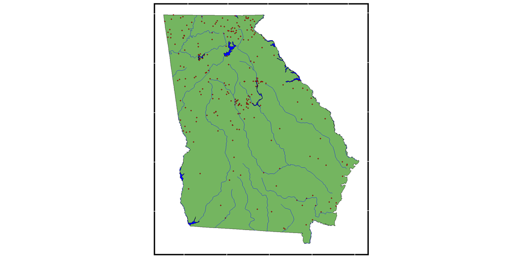

```r
ga_camp_rivers_plot <- RspatialPkg::get_geom_sf(
  sf = ga_state_sf,
  sf_fill = "#74b560",
  hide_x_tics = T,
  hide_y_tics = T
) +
  RspatialPkg::get_geom_sf(
    sf = ga_campgrounds_sf,
    sf_fill = "red",
    sf_size = 1,
    adding = T
  ) +
  RspatialPkg::get_geom_sf(
    sf = ne_data_lst[["rivers_north_america"]],
    sf_color = "blue",
    adding = T
  ) +
  RspatialPkg::get_geom_sf(
    sf = ne_data_lst[["lakes_north_america"]],
    sf_fill = "blue",
    adding = T
  ) +
  RspatialPkg::get_geom_sf(
    sf = ne_data_lst[["lakes"]],
    sf_fill = "blue",
    adding = T
  ) +
  RspatialPkg::get_geom_sf(
    sf = ne_data_lst[["rivers_lake_centerlines"]],
    sf_color = "blue",
    sf_linewidth = 0.3,
    adding = T
  )
ga_camp_rivers_plot
```

## 1.2 Option 1: Fill each county by the number of campgrounds

> One way to address this overplotting is to create bins with counts of the campgrounds in each bin.

> We’ll join the campground data to the county data with st_join() (which is the geographic equivalent of left_join()) and then use some group_by()

```r
ga_counties_campgrounds_sf <- ga_counties_sf %>%
  sf::st_join(., ga_campgrounds_sf) %>%
  data.table::as.data.table(.) %>%
  .[!is.na(DESCRIPTOR), .(COUNTY, geometry)] %>%
  .[, .(Total = .N,geometry), by = "COUNTY"] %>%
  sf::st_as_sf(.)
head(ga_counties_campgrounds_sf, 1)
```

```
Simple feature collection with 1 feature and 2 fields
Geometry type: MULTIPOLYGON
Dimension:     XY
Bounding box:  xmin: 347901.8 ymin: 3706423 xmax: 507579.1 ymax: 3822578
Projected CRS: NAD_1927_Georgia_Statewide_Albers
    COUNTY Total                       geometry
1 RICHMOND     2 MULTIPOLYGON (((348861.6 37...
```

Plot this new `ga_counties_campgrounds_sf` data and fill by Total.

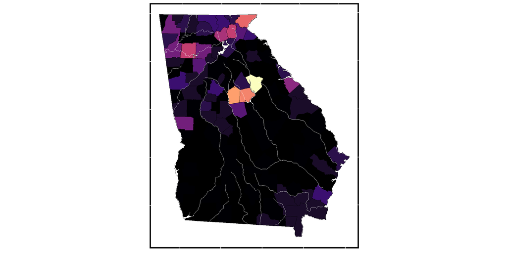

```r
ga_plot <-RspatialPkg::get_geom_sf(
    sf = ga_state_sf,
    sf_fill = "black",
    hide_x_tics = T,
    hide_y_tics = T) +
  RspatialPkg::get_geom_sf(
    sf = ga_counties_campgrounds_sf,
    aes_fill = "Total",
    sf_linewidth = 0.25,
    own_scale = T,
    adding = T
  ) +
  RspatialPkg::get_geom_sf(
    sf = ne_data_lst[["rivers_north_america"]],
    sf_color = "white",
    adding = T
  ) +
  RspatialPkg::get_geom_sf(
    sf = ne_data_lst[["lakes_north_america"]],
    sf_fill = "white",
    adding = T
  ) +
  RspatialPkg::get_geom_sf(
    sf = ne_data_lst[["lakes"]],
    sf_fill = "white",
    adding = T
  ) +
  RspatialPkg::get_geom_sf(
    sf = ne_data_lst[["rivers_lake_centerlines"]],
    sf_color = "white",
    sf_linewidth = 0.3,
    adding = T
  ) +
  ggplot2::scale_fill_viridis_c(option = "magma", guide = "none", na.value = "black")
ga_plot
```

> This already helps. We can see a cluster of campgrounds in central Georgia around the Piedmont National Wildlife Refuge and the Oconee National Forest, and another cluster in the mountains of northeast Georgia in the Chattahoochee-Oconee National forests.

## 1.3 Option 2: Create a grid and fill each grid box by the number of campgrounds

> We can use `st_make_grid()` to divide the state area up into a grid—here we’ll use 400 boxes

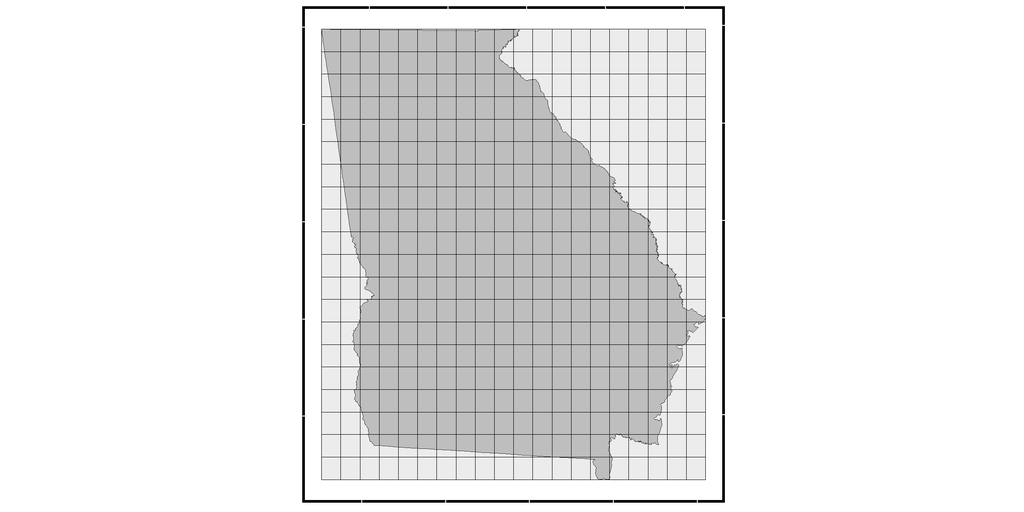

```r
ga_grid_sf <- ga_state_sf %>%
  sf::st_make_grid(n = c(20, 20)) %>%
  sf::st_as_sf(.) %>%
  data.table::as.data.table(.) %>%
  .[, grid_id := 1:nrow(.)] %>%
  sf::st_as_sf(.)

ga_grid_plot <- RspatialPkg::get_geom_sf(
  sf = ga_state_sf,
  hide_x_tics = T,
  hide_y_tics = T
) +
  RspatialPkg::get_geom_sf(
    sf = ga_grid_sf,
    sf_alpha = 0.3,
    adding = T
  )
ga_grid_plot
```

We can then use `st_intersection()` to cut the Georgia map into pieces that fall in each of those grid boxes.

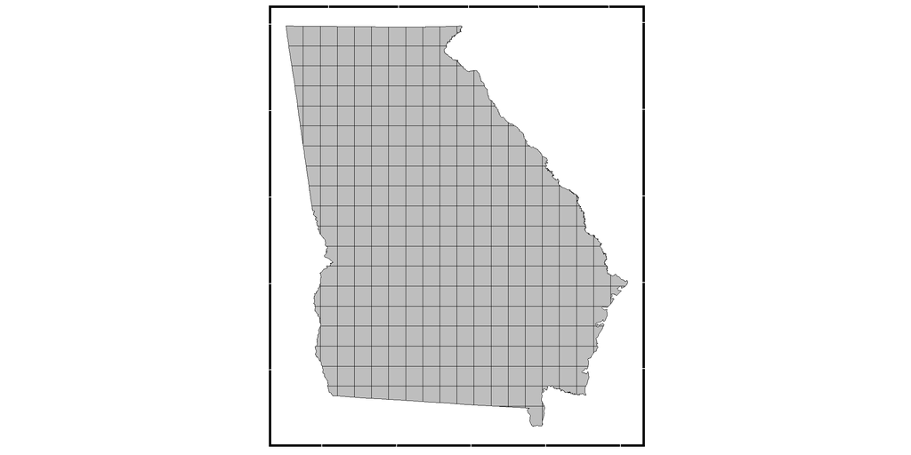

```r
ga_grid_map_sf <- sf::st_intersection(ga_state_sf, ga_grid_sf) %>%
  sf::st_as_sf(.)
ga_grid_map_plot <- RspatialPkg::get_geom_sf(
  sf = ga_grid_map_sf,
  hide_x_tics = T,
  hide_y_tics = T
)
ga_grid_map_plot
```

Next we can join the campground data to these boxes just like we did with the counties.

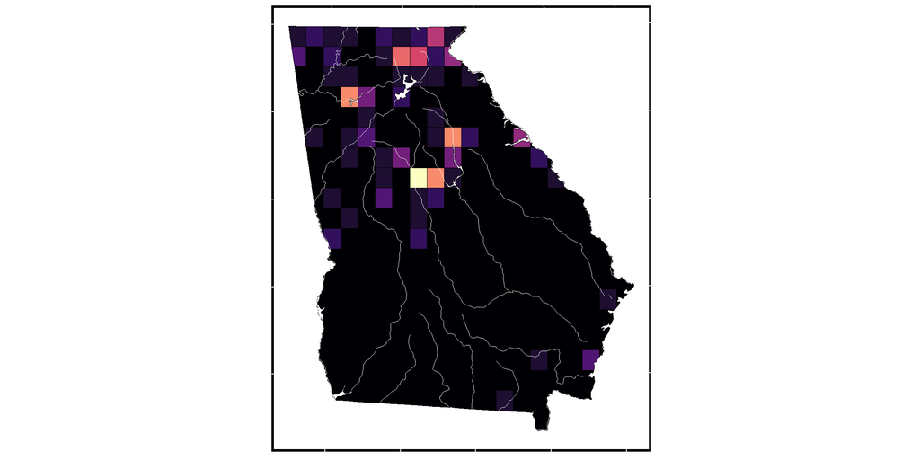

```r
campgrounds_per_grid_box_sf <- ga_grid_map_sf %>%
  sf::st_join(., ga_campgrounds_sf) %>%
  data.table::as.data.table(.) %>%
  .[, Total := .N, by = "grid_id"] %>%
  sf::st_as_sf(.)

campgrounds_per_grid_box_plot <- RspatialPkg::get_geom_sf(
    sf = ga_state_sf,
    sf_color = "black",
    sf_fill = NA,
    sf_linewidth = 0.25,
    hide_x_tics = T,
    hide_y_tics = T) +
  RspatialPkg::get_geom_sf(
    sf = campgrounds_per_grid_box_sf,
    aes_fill = "Total",
    own_scale = T,
    adding = T
  ) +
  RspatialPkg::get_geom_sf(
    sf = ne_data_lst[["rivers_north_america"]],
    sf_color = "white",
    adding = T
  ) +
  RspatialPkg::get_geom_sf(
    sf = ne_data_lst[["lakes_north_america"]],
    sf_fill = "white",
    adding = T
  ) +
  RspatialPkg::get_geom_sf(
    sf = ne_data_lst[["lakes"]],
    sf_fill = "white",
    adding = T
  ) +
  RspatialPkg::get_geom_sf(
    sf = ne_data_lst[["rivers_lake_centerlines"]],
    sf_color = "white",
    sf_linewidth = 0.3,
    adding = T
  ) +
  ggplot2::scale_fill_viridis_c(option = "magma", guide = "none", na.value = "black")

campgrounds_per_grid_box_plot
```

## 1.4 Option 3: Fill with a gradient of the density of the number of campgrounds

> To make the shading more accurate, we can turn to turn to calculus and imagine grid boxes that are infinitely small. We can calculate densities instead of binned or clustered subunits.

Convert our geometry column of `ga_campgrounds_sf` to a spatial point pattern object (or a ppp object) that {spatstat} can work with.

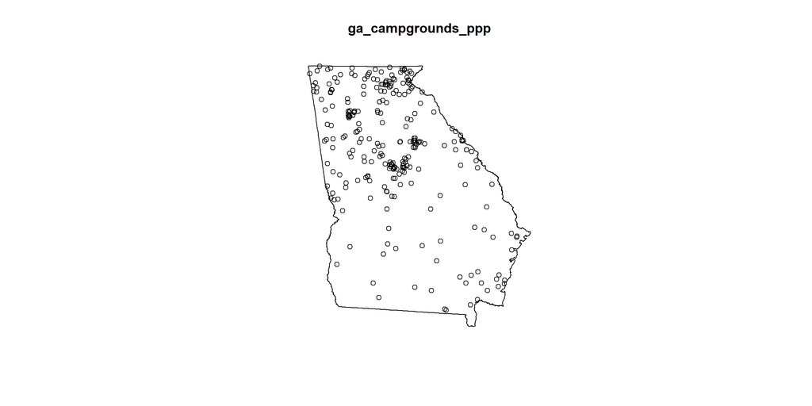

```r
ga_campgrounds_ppp <- as.ppp(ga_campgrounds_sf$geometry, W = as.owin(ga_state_sf))
plot(ga_campgrounds_ppp)
```

Create a stars object of the density of campground locations

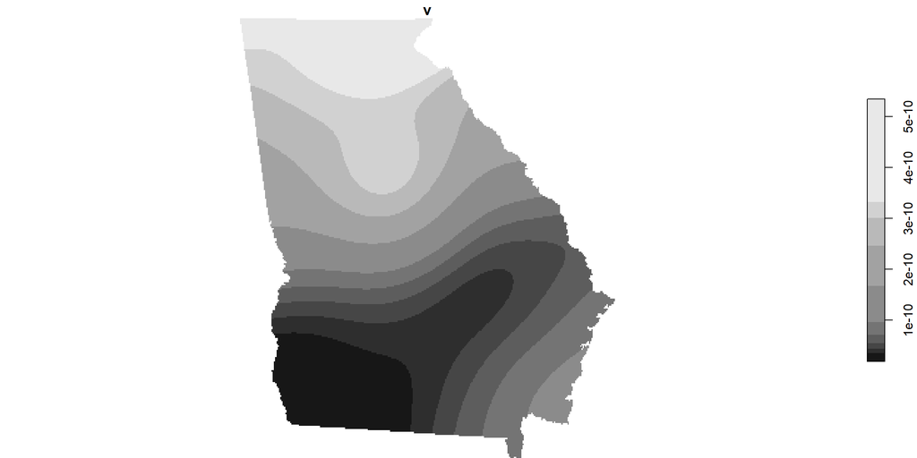

```r
density_campgrounds_stars <- stars::st_as_stars(density(ga_campgrounds_ppp, dimyx = 300))
plot(density_campgrounds_stars)
```

Convert this {stars} object back to {sf} so it’s normal and plottable with `geom_sf()`.

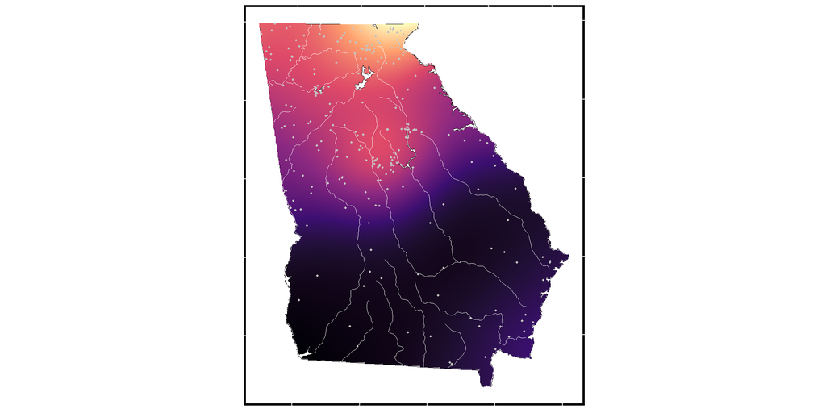

```r
ga_campgrounds_density_sf <- sf::st_as_sf(density_campgrounds_stars) %>%
  sf::st_set_crs(ga_crs)

campgrounds_density_plot <- RspatialPkg::get_geom_sf(
    sf = ga_state_sf,
    sf_color = "black",
    sf_fill = NA,
    sf_linewidth = 0.25,
    hide_x_tics = T,
    hide_y_tics = T) +
  RspatialPkg::get_geom_sf(
    sf = ga_campgrounds_density_sf,
    aes_fill = "v",
    own_scale = T,
    sf_color = NA,
    adding = T
  ) +
  RspatialPkg::get_geom_sf(
    sf = ne_data_lst[["rivers_north_america"]],
    sf_color = "white",
    adding = T
  ) +
  RspatialPkg::get_geom_sf(
    sf = ne_data_lst[["lakes_north_america"]],
    sf_fill = "white",
    adding = T
  ) +
  RspatialPkg::get_geom_sf(
    sf = ne_data_lst[["lakes"]],
    sf_fill = "white",
    adding = T
  ) +
  RspatialPkg::get_geom_sf(
    sf = ne_data_lst[["rivers_lake_centerlines"]],
    sf_color = "white",
    sf_linewidth = 0.3,
    adding = T
  ) +
  RspatialPkg::get_geom_sf(
    sf = ga_campgrounds_sf,
    sf_color = "grey80",
    sf_size = 1.0,
    adding = T
  ) +
  ggplot2::scale_fill_viridis_c(option = "magma", guide = "none", na.value = "black")
campgrounds_density_plot
```